# F75 Clinical Trial Analysis

2024-12-02

# Overview

This report summarizes the analyses performed on the **F75 Clinical Trial dataset**. The analyses focus on: - Baseline characteristics of participants. - Outcomes such as days to stabilization and discharge status. - Secondary outcomes, including mortality, adverse events, and changes in MUAC and weight.

# Data and Methods

The data were analyzed using the following scripts: - `analysis_baseline.R` for baseline characteristics. - `analysis_outcome1.R` for primary outcomes. - `analysis_outcome2.R` for secondary outcomes.

## Baseline Characteristics

The baseline analysis examines participants’ demographics and clinical status.

| age_mean | age_sd | weight_mean | weight_sd | height_mean | height_sd |
| --- | --- | --- | --- | --- | --- |
| 21.52632 | 17.52486 | 7.041092 | 2.289385 | 74.02035 | 10.21977 |

### Diarrhea Summary

| diarrhea_count | diarrhea_percentage |
| --- | --- |
| 271 | 52.82651 |
| 242 | 47.17349 |

### Kwashiorkor Summary

| kwashiorkor_count | kwashiorkor_percentage |
| --- | --- |
| 344 | 67.05653 |
| 169 | 32.94347 |

## Primary Outcomes

The primary outcome analysis evaluates **days to stabilization** and **discharge status**.

```
## here() starts at /Users/june/Documents/Git/data550_midterm_proj
```

Length of days_stable: 513 Length of arm: 513 Days to Stabilization Summary: # A tibble: 2 × 3 arm median_days iqr_days 1 Modified F75 (intervention) 3 4 2 Standard F75 3 4

Mann-Whitney U Test Results:

```
Wilcoxon rank sum test with continuity correction
```

data: days_stable by arm W = 33688, p-value = 0.6309 alternative hypothesis: true location shift is not equal to 0

Discharge Status Counts:

```
                           No Yes
```

Modified F75 (intervention) 66 192 Standard F75 50 205

| arm | median_days | iqr_days |
| --- | --- | --- |
| Modified F75 (intervention) | 3 | 4 |
| Standard F75 | 3 | 4 |

### Days to Stabilization Boxplot

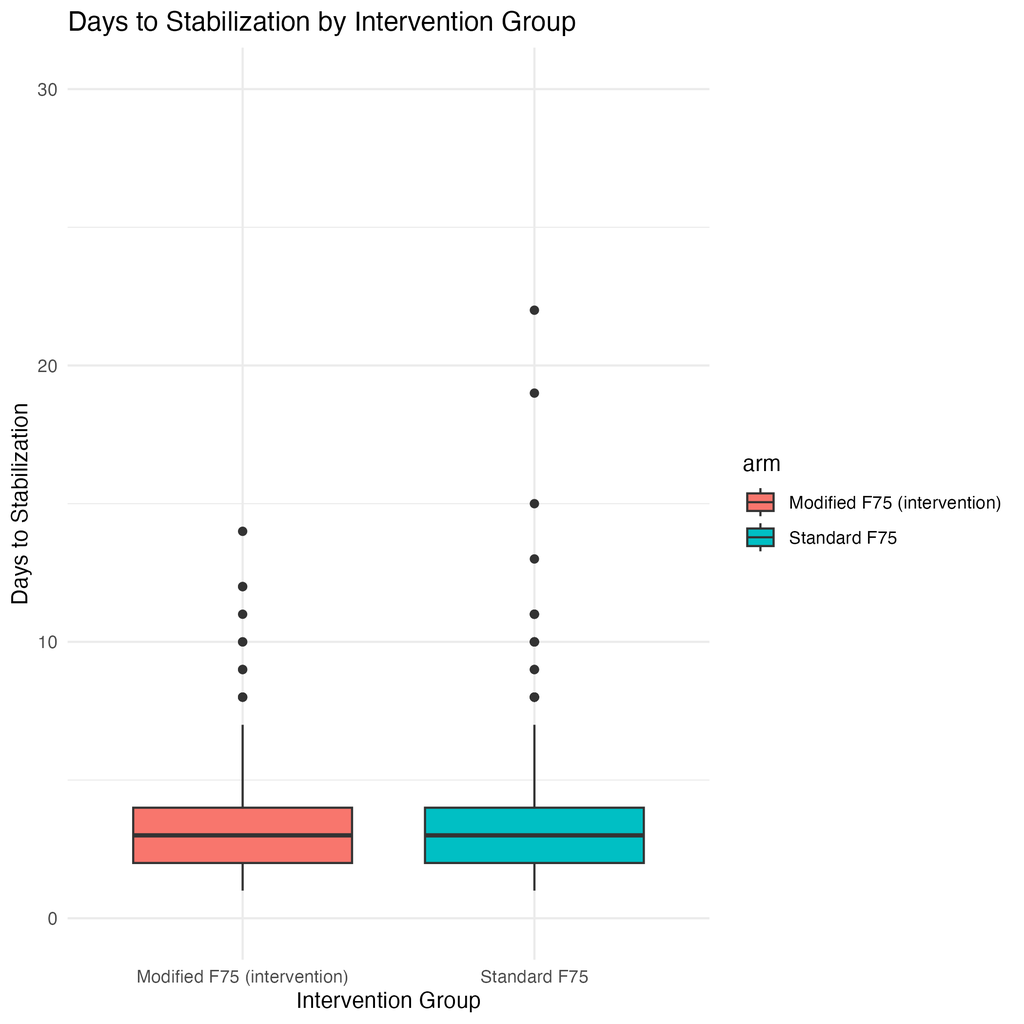

### Discharge Status

| X | No | Yes |
| --- | --- | --- |
| Modified F75 (intervention) | 66 | 192 |
| Standard F75 | 50 | 205 |

### Discharge Status Bar Chart

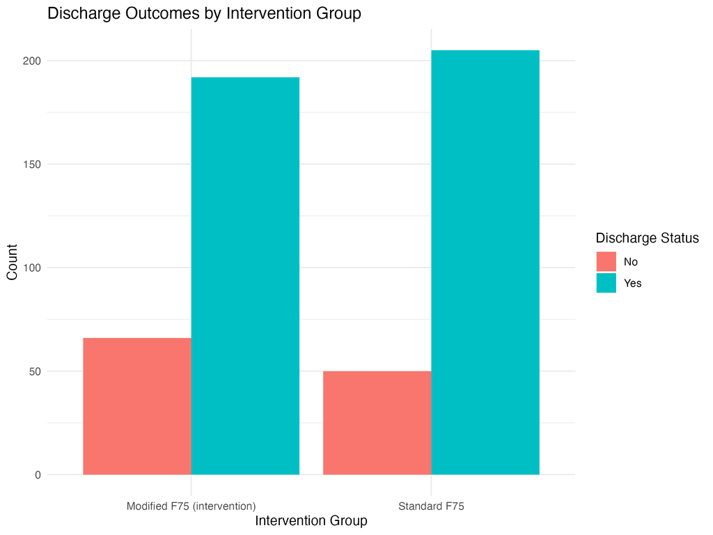

## Secondary Outcomes

The secondary outcomes include **mortality analysis**, **adverse events**, and **MUAC/weight changes**.

```
## here() starts at /Users/june/Documents/Git/data550_midterm_proj
```

| withdraw2 | count | percentage |
| --- | --- | --- |
| Absconded | 4 | 100 |
| Other | 25 | 100 |
| Voluntary withdrawal | 10 | 100 |
| died | 74 | 100 |
| withdrawn due to protocol violation | 3 | 100 |

### Mortality Bar Chart

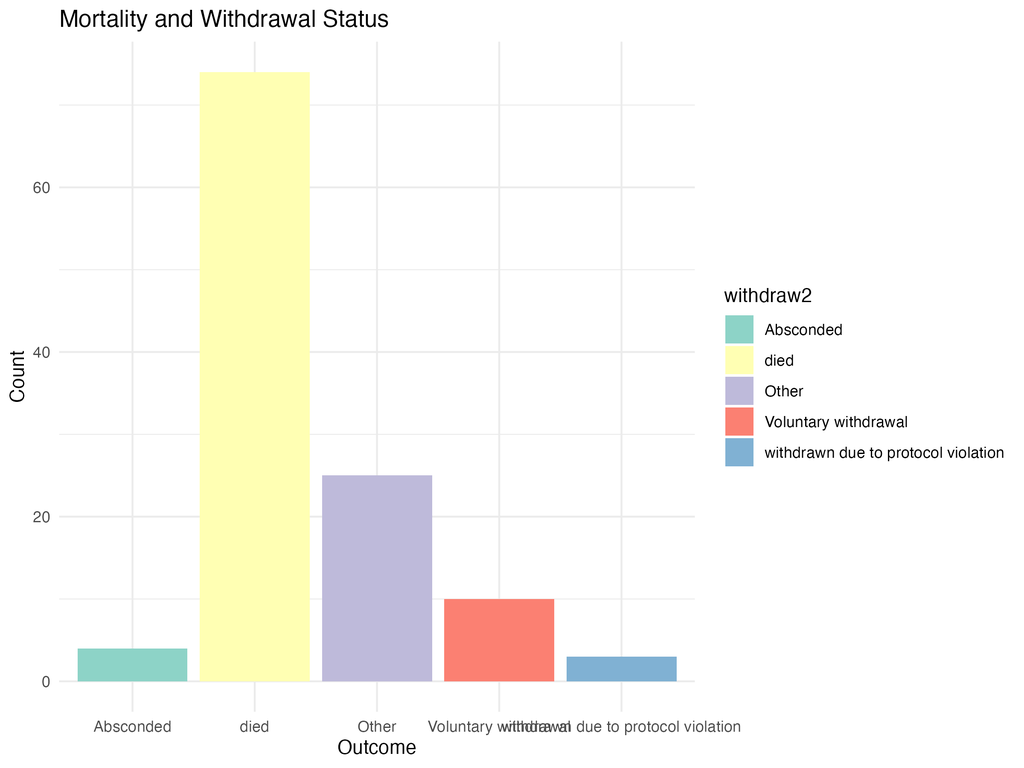

### Adverse Events Bar Chart

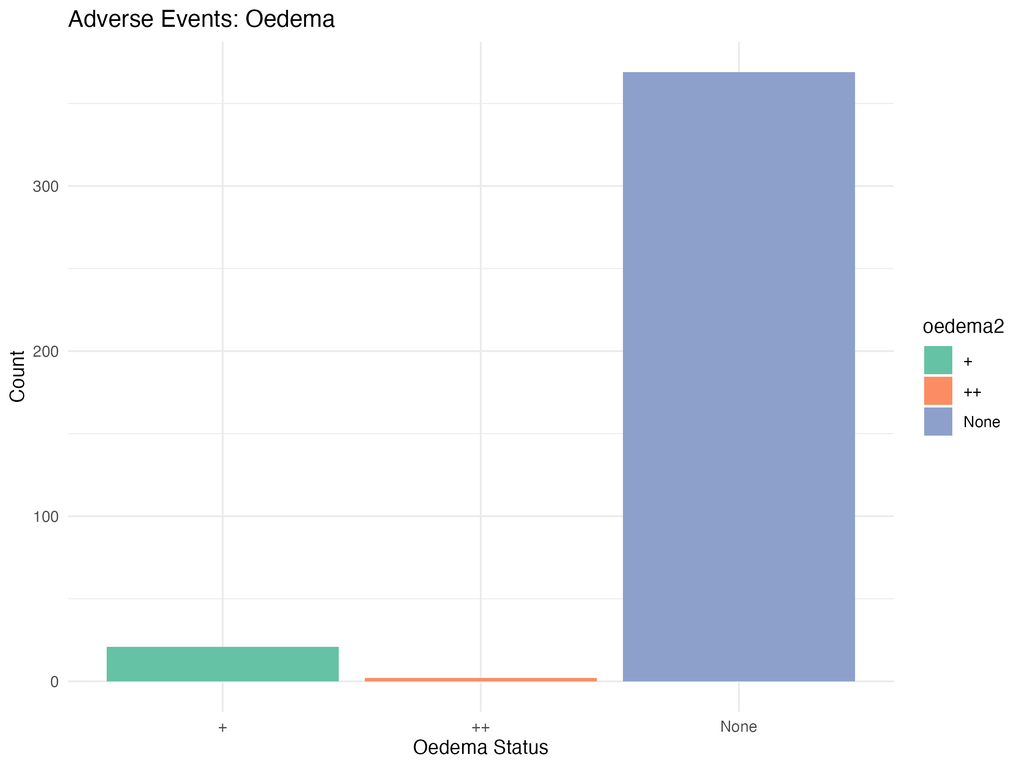

### MUAC Change Boxplot

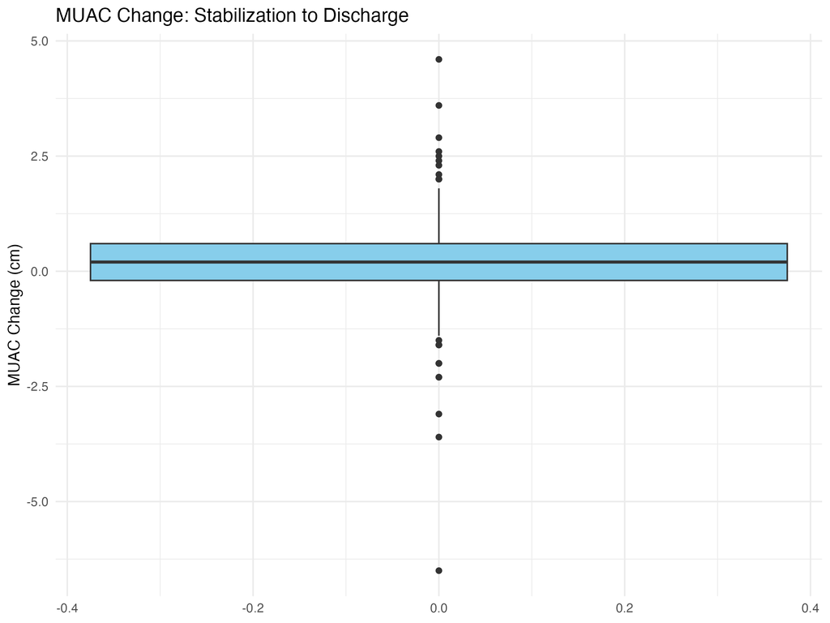

### Weight Change Boxplot

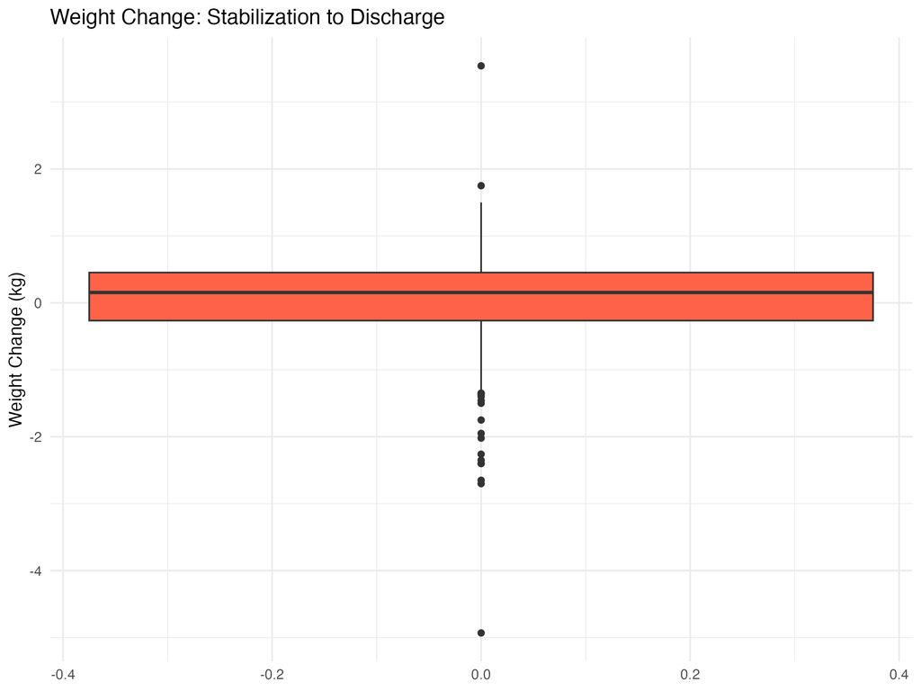

# Conclusion

The analyses reveal key insights about participants’ baseline characteristics, primary outcomes related to stabilization and discharge, and secondary outcomes, including mortality and clinical changes during the trial.

# Appendix

The full scripts used for the analyses are available in the `src/` directory for reproducibility.